### Author : Terry Migwi

### Time: 19th September 2020

### Week 14 IP - Dimensionality Reduction Techniques

# 1. Defining the Question

## Specifying the data analytic question

Perform Dimensionality reduction on the sales dataset provided

## Defining the metrics for success

This study will be considered succesful if:

- Both PCA and TSNE are performed with clear visualizations made and explained

## Understanding the Context

Dimensionality Reduction is reducing the number of variables in a dataset. Advantages of Dimensionality Reduction include:

- A reduction in storage space
- Fastens time required for computations
- Takes care of multi-collinearity
- Better visualization of data

This study is therefore important so as to avoid probelms such as overlapping, duplication in features or high features correlation that could arise from working with very large datasets.

## 2.Loading Data

```r
#reading the dataset
library(tidyverse)
sales <- read_csv("C:\\Users\\USER\\Downloads\\IP's datasets\\Module 3 Core - R Programming\\Supermarket_Dataset_1 - Sales Data.csv")
head(sales)
```

```
## # A tibble: 6 x 16
##   `Invoice ID` Branch `Customer type` Gender `Product line` `Unit price`
##   <chr>        <chr>  <chr>           <chr>  <chr>                 <dbl>
## 1 750-67-8428  A      Member          Female Health and be~         74.7
## 2 226-31-3081  C      Normal          Female Electronic ac~         15.3
## 3 631-41-3108  A      Normal          Male   Home and life~         46.3
## 4 123-19-1176  A      Member          Male   Health and be~         58.2
## 5 373-73-7910  A      Normal          Male   Sports and tr~         86.3
## 6 699-14-3026  C      Normal          Male   Electronic ac~         85.4
## # ... with 10 more variables: Quantity <dbl>, Tax <dbl>, Date <chr>,
## #   Time <time>, Payment <chr>, cogs <dbl>, `gross margin percentage` <dbl>,
## #   `gross income` <dbl>, Rating <dbl>, Total <dbl>
```

## 3.Checking the dataset

```r
#previewing the bottom part of the dataset
tail(sales)
```

```
## # A tibble: 6 x 16
##   `Invoice ID` Branch `Customer type` Gender `Product line` `Unit price`
##   <chr>        <chr>  <chr>           <chr>  <chr>                 <dbl>
## 1 652-49-6720  C      Member          Female Electronic ac~         61.0
## 2 233-67-5758  C      Normal          Male   Health and be~         40.4
## 3 303-96-2227  B      Normal          Female Home and life~         97.4
## 4 727-02-1313  A      Member          Male   Food and beve~         31.8
## 5 347-56-2442  A      Normal          Male   Home and life~         65.8
## 6 849-09-3807  A      Member          Female Fashion acces~         88.3
## # ... with 10 more variables: Quantity <dbl>, Tax <dbl>, Date <chr>,
## #   Time <time>, Payment <chr>, cogs <dbl>, `gross margin percentage` <dbl>,
## #   `gross income` <dbl>, Rating <dbl>, Total <dbl>
```

```r
# checking the size of the dataset

dim(sales)
```

```
## [1] 1000   16
```

The dataset has 1000 records with 16 variables

```r
# checking the structure of the dataset
str(sales)
```

```
## tibble [1,000 x 16] (S3: spec_tbl_df/tbl_df/tbl/data.frame)
##  $ Invoice ID             : chr [1:1000] "750-67-8428" "226-31-3081" "631-41-3108" "123-19-1176" ...
##  $ Branch                 : chr [1:1000] "A" "C" "A" "A" ...
##  $ Customer type          : chr [1:1000] "Member" "Normal" "Normal" "Member" ...
##  $ Gender                 : chr [1:1000] "Female" "Female" "Male" "Male" ...
##  $ Product line           : chr [1:1000] "Health and beauty" "Electronic accessories" "Home and lifestyle" "Health and beauty" ...
##  $ Unit price             : num [1:1000] 74.7 15.3 46.3 58.2 86.3 ...
##  $ Quantity               : num [1:1000] 7 5 7 8 7 7 6 10 2 3 ...
##  $ Tax                    : num [1:1000] 26.14 3.82 16.22 23.29 30.21 ...
##  $ Date                   : chr [1:1000] "1/5/2019" "3/8/2019" "3/3/2019" "1/27/2019" ...
##  $ Time                   : 'hms' num [1:1000] 13:08:00 10:29:00 13:23:00 20:33:00 ...
##   ..- attr(*, "units")= chr "secs"
##  $ Payment                : chr [1:1000] "Ewallet" "Cash" "Credit card" "Ewallet" ...
##  $ cogs                   : num [1:1000] 522.8 76.4 324.3 465.8 604.2 ...
##  $ gross margin percentage: num [1:1000] 4.76 4.76 4.76 4.76 4.76 ...
##  $ gross income           : num [1:1000] 26.14 3.82 16.22 23.29 30.21 ...
##  $ Rating                 : num [1:1000] 9.1 9.6 7.4 8.4 5.3 4.1 5.8 8 7.2 5.9 ...
##  $ Total                  : num [1:1000] 549 80.2 340.5 489 634.4 ...
##  - attr(*, "spec")=
##   .. cols(
##   ..   `Invoice ID` = col_character(),
##   ..   Branch = col_character(),
##   ..   `Customer type` = col_character(),
##   ..   Gender = col_character(),
##   ..   `Product line` = col_character(),
##   ..   `Unit price` = col_double(),
##   ..   Quantity = col_double(),
##   ..   Tax = col_double(),
##   ..   Date = col_character(),
##   ..   Time = col_time(format = ""),
##   ..   Payment = col_character(),
##   ..   cogs = col_double(),
##   ..   `gross margin percentage` = col_double(),
##   ..   `gross income` = col_double(),
##   ..   Rating = col_double(),
##   ..   Total = col_double()
##   .. )
```

```r
# checking for number of unique values in each variable

lapply(sales, function(x) {length(unique(x))})
```

```
## $`Invoice ID`
## [1] 1000
##
## $Branch
## [1] 3
##
## $`Customer type`
## [1] 2
##
## $Gender
## [1] 2
##
## $`Product line`
## [1] 6
##
## $`Unit price`
## [1] 943
##
## $Quantity
## [1] 10
##
## $Tax
## [1] 990
##
## $Date
## [1] 89
##
## $Time
## [1] 506
##
## $Payment
## [1] 3
##
## $cogs
## [1] 990
##
## $`gross margin percentage`
## [1] 1
##
## $`gross income`
## [1] 990
##
## $Rating
## [1] 61
##
## $Total
## [1] 990
```

*Observations*

- Incoice ID variable has 1000 unique values hence it has high cardinality
- Branch, customer type, gender, product line, quantity and payment are factor variables
- Gross margin percentage has just one unique value

```r
# checking for missing values
colSums(is.na(sales))
```

```
##              Invoice ID                  Branch           Customer type
##                       0                       0                       0
##                  Gender            Product line              Unit price
##                       0                       0                       0
##                Quantity                     Tax                    Date
##                       0                       0                       0
##                    Time                 Payment                    cogs
##                       0                       0                       0
## gross margin percentage            gross income                  Rating
##                       0                       0                       0
##                   Total
##                       0
```

Our dataset does NOT contain any missing values

```r
# checking for duplicated values
duplicated_rows <- sales[duplicated(sales), ]

# all unique records
unique_items <- sales[!duplicated(sales), ]
dim(unique_items)
```

```
## [1] 1000   16
```

The dataset does Not contain any duplicate records

**Outliers**

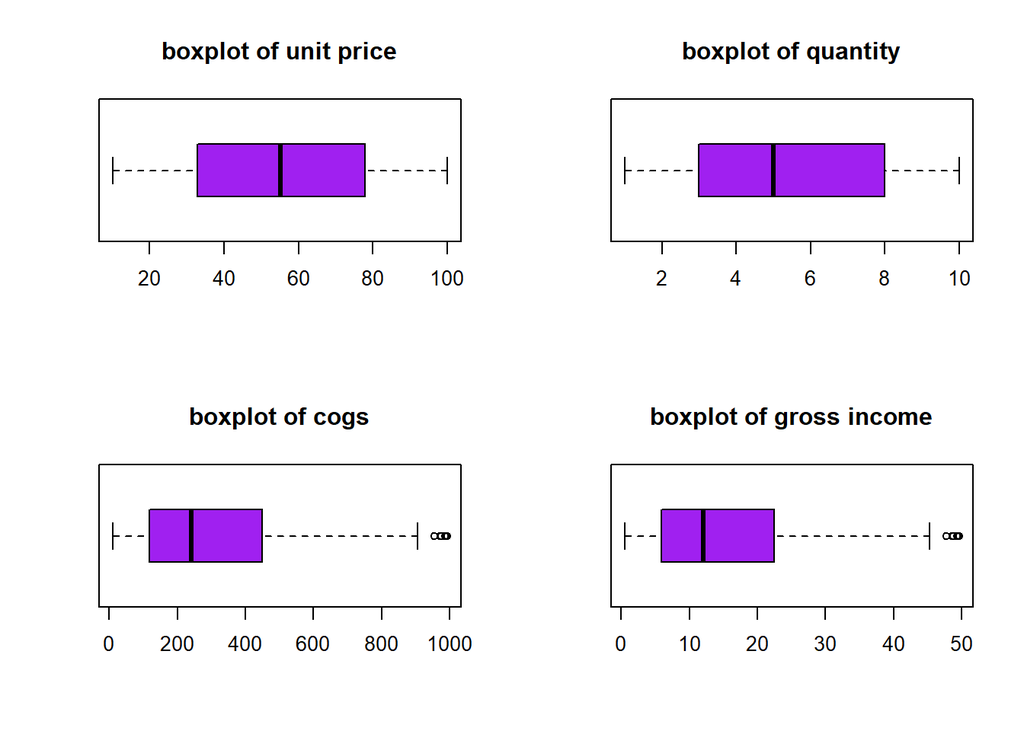

```r
#plotting box plots of numerical variables
par(mfrow=c(2,2))
boxplot((sales$`Unit price`), horizontal = TRUE, col = 'purple', main = "boxplot of unit price")
boxplot((sales$`Quantity`), horizontal = TRUE, col = 'purple', main = "boxplot of quantity")
#boxplot((sales$`Payment`), horizontal = TRUE, col = 'purple', main = "boxplot of Payment")
boxplot((sales$`cogs`), horizontal = TRUE, col = 'purple', main = "boxplot of cogs")
#boxplot((sales$`gross margin percentage`), horizontal = TRUE, col = 'purple', main = "boxplot of gross margin percentage")
boxplot((sales$`gross income`), horizontal = TRUE, col = 'purple', main = "boxplot of gross income")
```

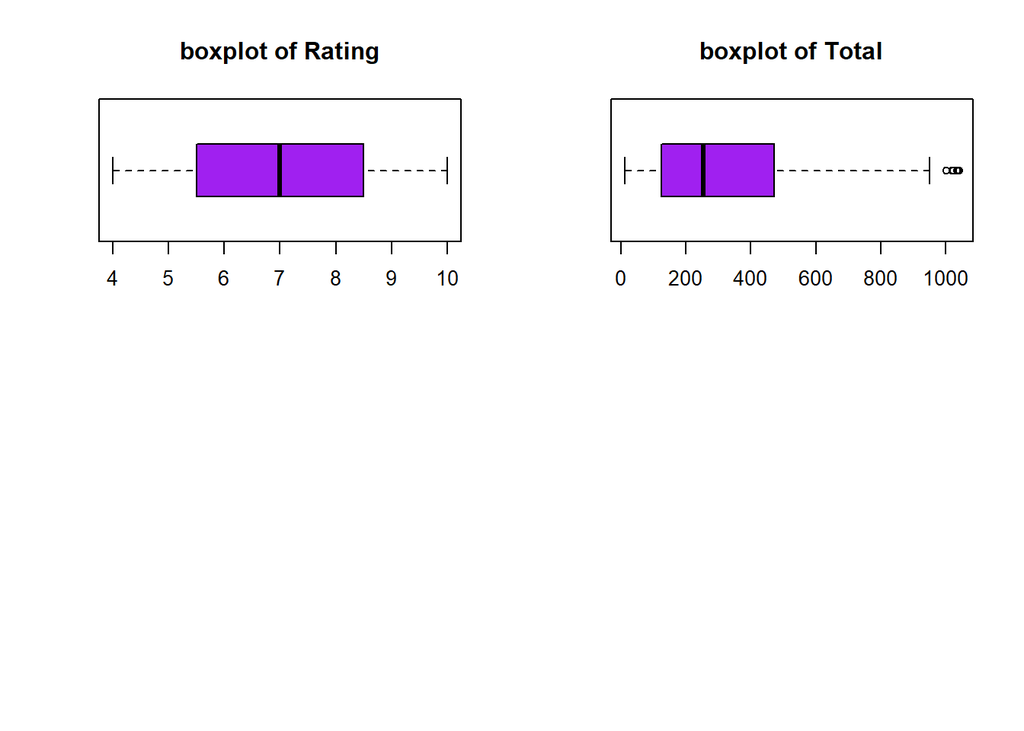

```r
boxplot((sales$`Rating`), horizontal = TRUE, col = 'purple', main = "boxplot of Rating")
boxplot((sales$`Total`), horizontal = TRUE, col = 'purple', main = "boxplot of Total")
```

*Observations*

*Variables cogs, gross income and total has a few outlier observations

## 4.Data Pre-processing

```r
#converting date variable to date datatype

sales$Date <- as.Date(sales$Date, format = "%m/%d/%Y")

#separating the date column to day, month and year
sales <- separate(sales, "Date", c("Year", "Month", "Day"), sep = "-")

# checking if the changes have been effected
str(sales)
```

```
## tibble [1,000 x 18] (S3: tbl_df/tbl/data.frame)
##  $ Invoice ID             : chr [1:1000] "750-67-8428" "226-31-3081" "631-41-3108" "123-19-1176" ...
##  $ Branch                 : chr [1:1000] "A" "C" "A" "A" ...
##  $ Customer type          : chr [1:1000] "Member" "Normal" "Normal" "Member" ...
##  $ Gender                 : chr [1:1000] "Female" "Female" "Male" "Male" ...
##  $ Product line           : chr [1:1000] "Health and beauty" "Electronic accessories" "Home and lifestyle" "Health and beauty" ...
##  $ Unit price             : num [1:1000] 74.7 15.3 46.3 58.2 86.3 ...
##  $ Quantity               : num [1:1000] 7 5 7 8 7 7 6 10 2 3 ...
##  $ Tax                    : num [1:1000] 26.14 3.82 16.22 23.29 30.21 ...
##  $ Year                   : chr [1:1000] "2019" "2019" "2019" "2019" ...
##  $ Month                  : chr [1:1000] "01" "03" "03" "01" ...
##  $ Day                    : chr [1:1000] "05" "08" "03" "27" ...
##  $ Time                   : 'hms' num [1:1000] 13:08:00 10:29:00 13:23:00 20:33:00 ...
##   ..- attr(*, "units")= chr "secs"
##  $ Payment                : chr [1:1000] "Ewallet" "Cash" "Credit card" "Ewallet" ...
##  $ cogs                   : num [1:1000] 522.8 76.4 324.3 465.8 604.2 ...
##  $ gross margin percentage: num [1:1000] 4.76 4.76 4.76 4.76 4.76 ...
##  $ gross income           : num [1:1000] 26.14 3.82 16.22 23.29 30.21 ...
##  $ Rating                 : num [1:1000] 9.1 9.6 7.4 8.4 5.3 4.1 5.8 8 7.2 5.9 ...
##  $ Total                  : num [1:1000] 549 80.2 340.5 489 634.4 ...
```

## 5.Univariate Analysis

```r
# statistical summary of the dataset
summary(sales)
```

```
##   Invoice ID           Branch          Customer type         Gender
##  Length:1000        Length:1000        Length:1000        Length:1000
##  Class :character   Class :character   Class :character   Class :character
##  Mode  :character   Mode  :character   Mode  :character   Mode  :character
##
##
##
##  Product line         Unit price       Quantity          Tax
##  Length:1000        Min.   :10.08   Min.   : 1.00   Min.   : 0.5085
##  Class :character   1st Qu.:32.88   1st Qu.: 3.00   1st Qu.: 5.9249
##  Mode  :character   Median :55.23   Median : 5.00   Median :12.0880
##                     Mean   :55.67   Mean   : 5.51   Mean   :15.3794
##                     3rd Qu.:77.94   3rd Qu.: 8.00   3rd Qu.:22.4453
##                     Max.   :99.96   Max.   :10.00   Max.   :49.6500
##      Year              Month               Day                Time
##  Length:1000        Length:1000        Length:1000        Length:1000
##  Class :character   Class :character   Class :character   Class1:hms
##  Mode  :character   Mode  :character   Mode  :character   Class2:difftime
##                                                           Mode  :numeric
##
##
##    Payment               cogs        gross margin percentage  gross income
##  Length:1000        Min.   : 10.17   Min.   :4.762           Min.   : 0.5085
##  Class :character   1st Qu.:118.50   1st Qu.:4.762           1st Qu.: 5.9249
##  Mode  :character   Median :241.76   Median :4.762           Median :12.0880
##                     Mean   :307.59   Mean   :4.762           Mean   :15.3794
##                     3rd Qu.:448.90   3rd Qu.:4.762           3rd Qu.:22.4453
##                     Max.   :993.00   Max.   :4.762           Max.   :49.6500
##      Rating           Total
##  Min.   : 4.000   Min.   :  10.68
##  1st Qu.: 5.500   1st Qu.: 124.42
##  Median : 7.000   Median : 253.85
##  Mean   : 6.973   Mean   : 322.97
##  3rd Qu.: 8.500   3rd Qu.: 471.35
##  Max.   :10.000   Max.   :1042.65
```

```r
library(psych)
describe(sales)
```

```
##                         vars    n   mean     sd median trimmed    mad   min
## Invoice ID*                1 1000 500.50 288.82 500.50  500.50 370.65  1.00
## Branch*                    2 1000   1.99   0.82   2.00    1.99   1.48  1.00
## Customer type*             3 1000   1.50   0.50   1.00    1.50   0.00  1.00
## Gender*                    4 1000   1.50   0.50   1.00    1.50   0.00  1.00
## Product line*              5 1000   3.45   1.72   3.00    3.44   1.48  1.00
## Unit price                 6 1000  55.67  26.49  55.23   55.62  33.37 10.08
## Quantity                   7 1000   5.51   2.92   5.00    5.51   2.97  1.00
## Tax                        8 1000  15.38  11.71  12.09   14.00  11.13  0.51
## Year*                      9 1000   1.00   0.00   1.00    1.00   0.00  1.00
## Month*                    10 1000   1.99   0.84   2.00    1.99   1.48  1.00
## Day*                      11 1000  15.26   8.69  15.00   15.21  11.86  1.00
## Time                      12 1000    NaN     NA     NA     NaN     NA   Inf
## Payment*                  13 1000   2.00   0.83   2.00    2.00   1.48  1.00
## cogs                      14 1000 307.59 234.18 241.76  279.91 222.65 10.17
## gross margin percentage   15 1000   4.76   0.00   4.76    4.76   0.00  4.76
## gross income              16 1000  15.38  11.71  12.09   14.00  11.13  0.51
## Rating                    17 1000   6.97   1.72   7.00    6.97   2.22  4.00
## Total                     18 1000 322.97 245.89 253.85  293.91 233.78 10.68
##                             max   range skew kurtosis   se
## Invoice ID*             1000.00  999.00 0.00    -1.20 9.13
## Branch*                    3.00    2.00 0.02    -1.51 0.03
## Customer type*             2.00    1.00 0.00    -2.00 0.02
## Gender*                    2.00    1.00 0.00    -2.00 0.02
## Product line*              6.00    5.00 0.06    -1.28 0.05
## Unit price                99.96   89.88 0.01    -1.22 0.84
## Quantity                  10.00    9.00 0.01    -1.22 0.09
## Tax                       49.65   49.14 0.89    -0.09 0.37
## Year*                      1.00    0.00  NaN      NaN 0.00
## Month*                     3.00    2.00 0.01    -1.57 0.03
## Day*                      31.00   30.00 0.05    -1.23 0.27
## Time                       -Inf    -Inf   NA       NA   NA
## Payment*                   3.00    2.00 0.00    -1.55 0.03
## cogs                     993.00  982.83 0.89    -0.09 7.41
## gross margin percentage    4.76    0.00  NaN      NaN 0.00
## gross income              49.65   49.14 0.89    -0.09 0.37
## Rating                    10.00    6.00 0.01    -1.16 0.05
## Total                   1042.65 1031.97 0.89    -0.09 7.78
```

**Histograms**

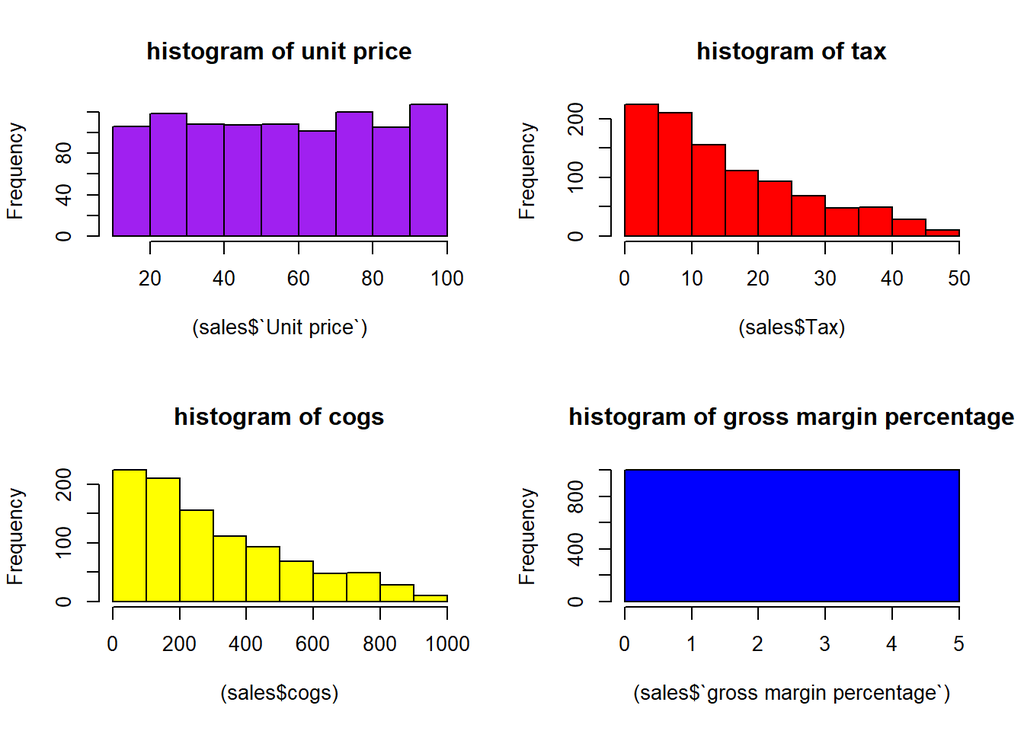

```r
#plotting histograms for all numerical variables
par(mfrow=c(2,2))
#histogram of unit price
hist((sales$`Unit price`), col = 'purple', main = "histogram of unit price")

#histogram of tax
hist((sales$`Tax`), col = 'red', main = "histogram of tax")

#histogram of cogs
hist((sales$'cogs'), col = 'yellow', main = "histogram of cogs")

#histogram of gross margin percentage
hist((sales$`gross margin percentage`), col = 'blue', main = "histogram of gross margin percentage")
```

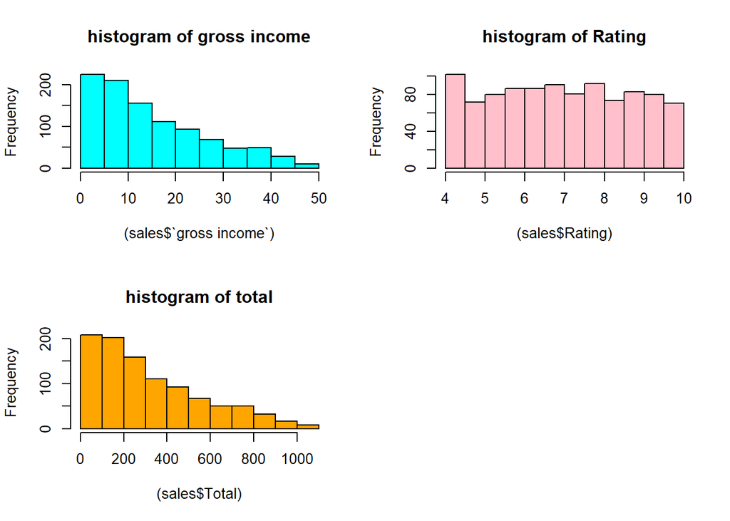

```r
#histogram of gross income
hist((sales$`gross income`), col = 'cyan', main = "histogram of gross income")

#histogram of rating
hist((sales$`Rating`), col = 'pink', main = "histogram of Rating")

#histogram of total
hist((sales$`Total`), col = 'orange', main = "histogram of total")
```

**Bar plots**

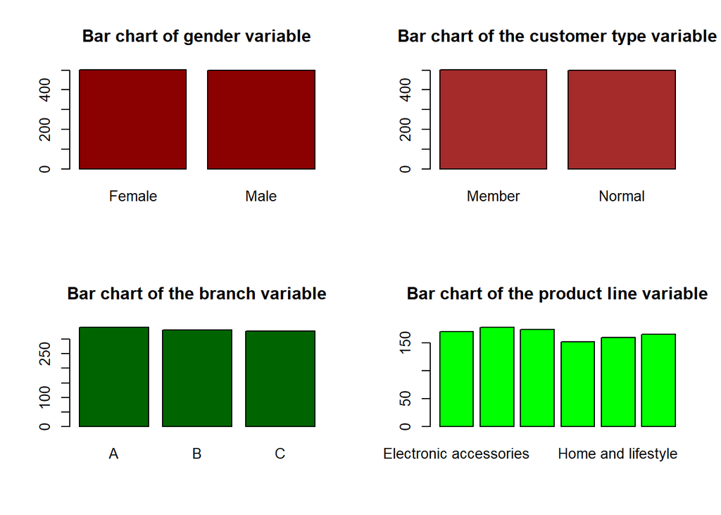

```r
#bar charts of categorical variables (Branch, Customer type, Gender, Product line, quantity, rating)
gender<-sales$Gender                #locating the gender variable
gender_frequency<- table(gender)    #assigning a frequency table to the variable

customer <- sales$`Customer type`     #fetching the customer type variable
customer_frequency<- table(customer)  #assigning a frequency table to the variable

branch <- sales$Branch
branch_frequency <- table(branch)

product <- sales$`Product line`
product_frequency <- table(product)

quantity <- sales$`Quantity`
quantity_frequency <- table(quantity)

payment <- sales$`Payment`
payment_frequency <- table(payment)

day <- sales$`Day`
day_frequency <- table(day)

month <- sales$`Month`
month_frequency <- table(month)

year <- sales$`Year`
year_frequency <- table(year)


#plotting bar charts using the frequency tables
par(mfrow=c(2,2))
barplot((gender_frequency), col = "darkred", main = "Bar chart of gender variable")
barplot((customer_frequency), col = "brown", main = "Bar chart of the customer type variable")
barplot((branch_frequency), col = "darkgreen", main = "Bar chart of the branch variable")
barplot((product_frequency), col = "green", main = "Bar chart of the product line variable")
```

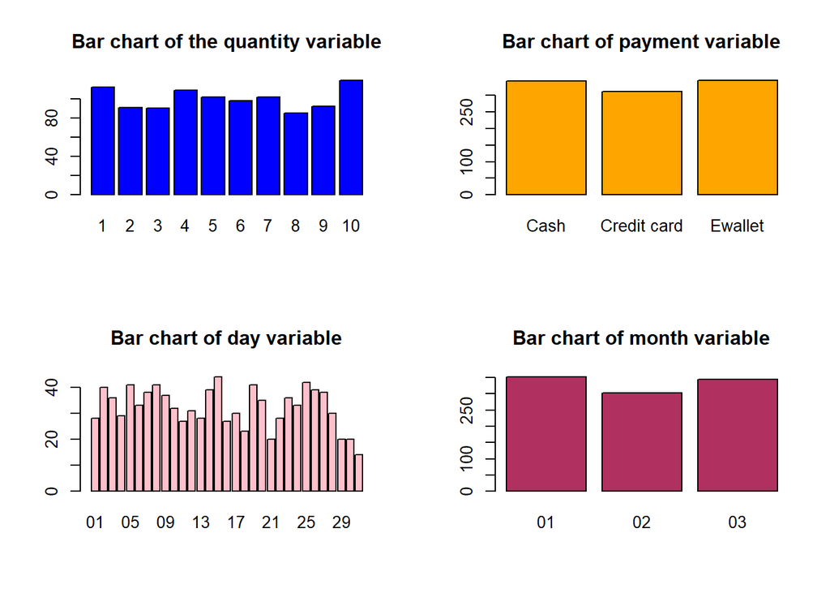

```r
barplot((quantity_frequency), col = "blue", main = "Bar chart of the quantity variable")
barplot((payment_frequency), col = "orange", main = "Bar chart of payment variable")
barplot((day_frequency), col = "pink", main = "Bar chart of day variable")
barplot((month_frequency), col = "maroon", main = "Bar chart of month variable")
```

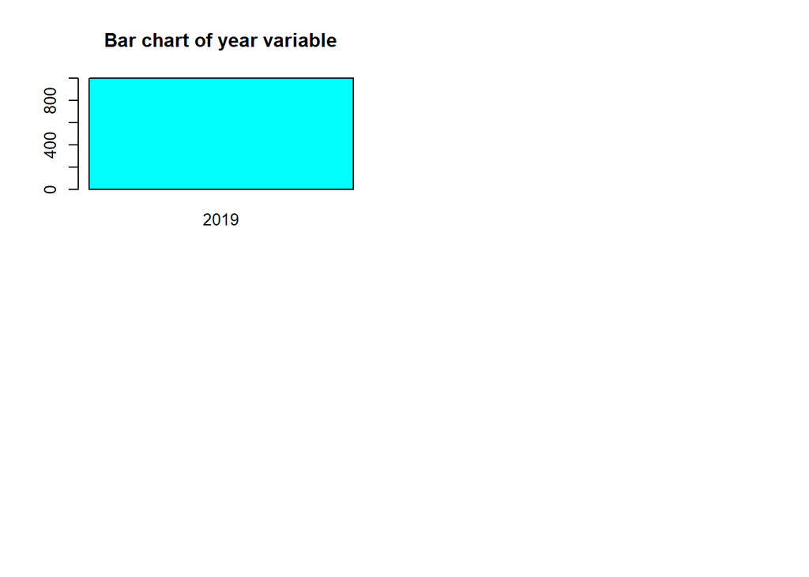

```r
barplot((year_frequency), col = "cyan", main = "Bar chart of year variable")
```

**Observations**

- In the gender variable, Males and Females have been equally represented
- We have three branches (A, B and C), wher all branches have equal representation
- In the product line variable, Electronic accessories are generally more than home and lifestyle accessories
- In the quantity variable, quantity 10 and 1 are the most frequent
- The payment varible has 3 modes of payment, (cash, credit card and Ewallet). Cash and Ewallet are the most used modes of payment
- There are only three months and 1 year represented in the dataset

## 6.Bivariate Analysis

```r
library(ggcorrplot)
```

```r
#fetching all the numerical continous variables from the dataset

unit <- sales$`Unit price`    #fetching the unit price variable
#quantity <- sales$Quantity    #fetching the quantity variable
tax <- sales$Tax              #fetching the tax variable
cogs <-sales$cogs             #fetching cogs
income <-sales$`gross income`
rating <-sales$Rating
total <-sales$Total

#creating a new dataframe num with numerical variables
num<- data.frame(unit, tax, cogs, income, rating, total)
head(num)    #previewing the dataframe
```

```
##    unit     tax   cogs  income rating    total
## 1 74.69 26.1415 522.83 26.1415    9.1 548.9715
## 2 15.28  3.8200  76.40  3.8200    9.6  80.2200
## 3 46.33 16.2155 324.31 16.2155    7.4 340.5255
## 4 58.22 23.2880 465.76 23.2880    8.4 489.0480
## 5 86.31 30.2085 604.17 30.2085    5.3 634.3785
## 6 85.39 29.8865 597.73 29.8865    4.1 627.6165
```

```r
#calculating a correlation matrix of the dataframe created

corr <- round(cor(num), 1)
head(corr[, 1:4])   #previewing the matrix
```

```
##        unit tax cogs income
## unit    1.0 0.6  0.6    0.6
## tax     0.6 1.0  1.0    1.0
## cogs    0.6 1.0  1.0    1.0
## income  0.6 1.0  1.0    1.0
## rating  0.0 0.0  0.0    0.0
## total   0.6 1.0  1.0    1.0
```

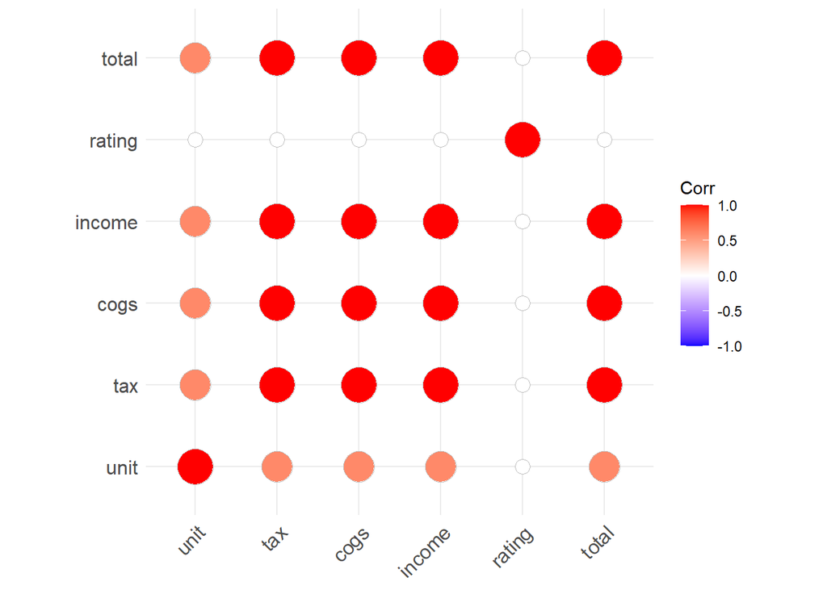

```r
#visualizing correlation matrix

ggcorrplot(corr, method = "circle")
```

** Scatter plots**

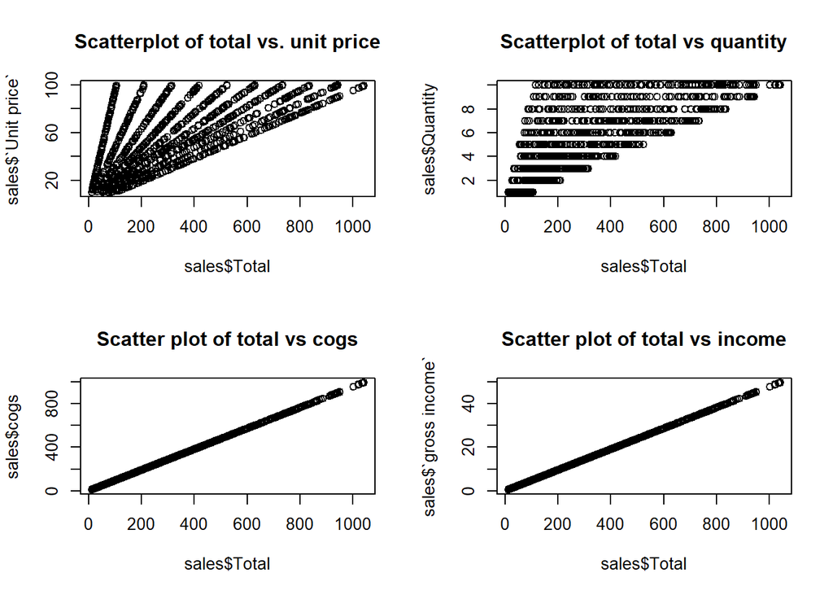

```r
#scatter plots to show the relationship above

par(mfrow=c(2,2))
plot(sales$`Total`, sales$`Unit price`, main="Scatterplot of total vs. unit price")
plot(sales$Total,sales$Quantity, main="Scatterplot of total vs quantity")
plot(sales$Total, sales$cogs, main="Scatter plot of total vs cogs")
plot(sales$Total, sales$`gross income`,main="Scatter plot of total vs income")
```

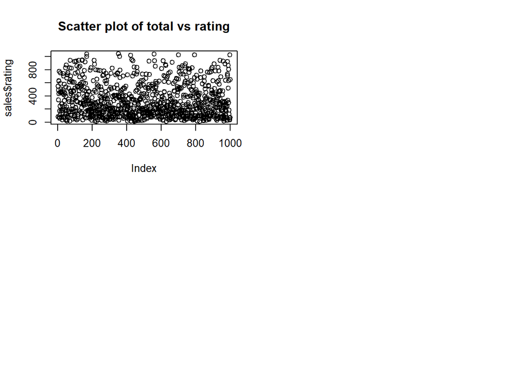

```r
plot(sales$Total, sales$`rating`,main="Scatter plot of total vs rating")
```

- variables total and cogs have a stong linear relationship
- Variables total and gross income have a strong linear relationship
- Variables total and unit price seem to also have a linear relationship

## 7.Principal Component Analysis (PCA)

Principal components analysis (PCA) is a method for finding low-dimensional representations of a data set that retain as much of the original variation as possible. The idea is that each of the n observations lives in p-dimensional space, but not all of these dimensions are equally interesting. In PCA we look for a smaller number of dimensions that are as interesting as possible, where the concept of interesting is measured by the amount that the observations vary along each dimension. Each of the new dimensions found in PCA is a linear combination of the original p features

### Data Pre-processing

- PCA is sensitive to scale of measurement thus we should always standardize variables before applying PCA
- PCA can only be applied to numerical data hence categorical variables need to be convereted to numerical data

```r
#str(sales)
```

```r
#selecting only numeric variables and omiting categorical variables (Invoice ID, branch, customer type, gender, product line, year, month, day, Time and payment)
sales.1 <- sales[, c(6:8,14,16:18)]
head(sales.1)
```

```
## # A tibble: 6 x 7
##   `Unit price` Quantity   Tax  cogs `gross income` Rating Total
##          <dbl>    <dbl> <dbl> <dbl>          <dbl>  <dbl> <dbl>
## 1         74.7        7 26.1  523.           26.1     9.1 549.
## 2         15.3        5  3.82  76.4           3.82    9.6  80.2
## 3         46.3        7 16.2  324.           16.2     7.4 341.
## 4         58.2        8 23.3  466.           23.3     8.4 489.
## 5         86.3        7 30.2  604.           30.2     5.3 634.
## 6         85.4        7 29.9  598.           29.9     4.1 628.
```

```r
#normalizing numerical variables
#function to normalize
#normalize <- function(x) {
 # return ((x - min(x)) / (max(x) - min(x)))
#}

#applying function to numerical variables
#sales$`Unit price` <- normalize(sales$`Unit price`)
#sales$Tax <- normalize(sales$Tax)
#sales$cogs <- normalize(sales$cogs)
#sales$`gross margin percentage` <- normalize(sales$`gross margin percentage`)
#sales$`gross income` <- normalize(sales$`gross income`)
#sales$Rating <- normalize(sales$Rating)
#sales$Total <- normalize(sales$Total)


# one hot encoding categorical variables
#library(caret)

#dmy <- dummyVars(" ~ .", data = sales, fullRank = T)
#dat_transformed <- data.frame(predict(dmy, newdata = sales))

#glimpse(dat_transformed)
```

```r
#applying pca by passing data to prcomp
sales.pca <- prcomp(sales.1, center = TRUE, scale. = TRUE)
summary(sales.pca)
```

```
## Importance of components:
##                           PC1    PC2    PC3     PC4       PC5       PC6
## Standard deviation     2.2185 1.0002 0.9939 0.30001 2.981e-16 1.493e-16
## Proportion of Variance 0.7031 0.1429 0.1411 0.01286 0.000e+00 0.000e+00
## Cumulative Proportion  0.7031 0.8460 0.9871 1.00000 1.000e+00 1.000e+00
##                              PC7
## Standard deviation     9.831e-17
## Proportion of Variance 0.000e+00
## Cumulative Proportion  1.000e+00
```

From the above, we have a total of 7 PCA components, out of which 4 will give us 100% of the information hence the other three components have very negligible contribution.

```r
str(sales.pca)
```

```
## List of 5
##  $ sdev    : num [1:7] 2.22 1.00 9.94e-01 3.00e-01 2.98e-16 ...
##  $ rotation: num [1:7, 1:7] -0.292 -0.325 -0.45 -0.45 -0.45 ...
##   ..- attr(*, "dimnames")=List of 2
##   .. ..$ : chr [1:7] "Unit price" "Quantity" "Tax" "cogs" ...
##   .. ..$ : chr [1:7] "PC1" "PC2" "PC3" "PC4" ...
##  $ center  : Named num [1:7] 55.67 5.51 15.38 307.59 15.38 ...
##   ..- attr(*, "names")= chr [1:7] "Unit price" "Quantity" "Tax" "cogs" ...
##  $ scale   : Named num [1:7] 26.49 2.92 11.71 234.18 11.71 ...
##   ..- attr(*, "names")= chr [1:7] "Unit price" "Quantity" "Tax" "cogs" ...
##  $ x       : num [1:1000, 1:7] -2.005 2.306 -0.186 -1.504 -2.8 ...
##   ..- attr(*, "dimnames")=List of 2
##   .. ..$ : NULL
##   .. ..$ : chr [1:7] "PC1" "PC2" "PC3" "PC4" ...
##  - attr(*, "class")= chr "prcomp"
```

```r
# Installing our ggbiplot visualisation package
#
library(devtools)
#install_github("vqv/ggbiplot")
```

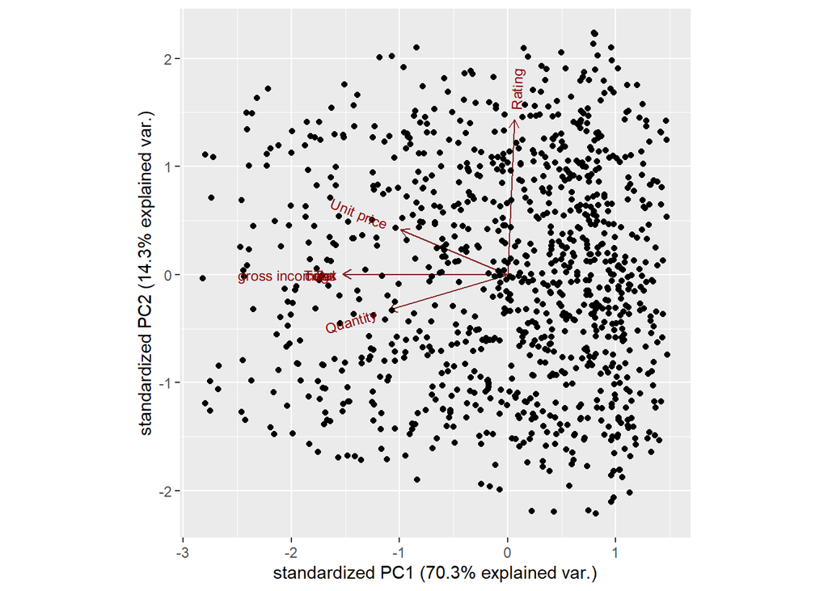

```r
library(ggbiplot)
#plotting Principal Components 1 and 2
ggbiplot(sales.pca)
```

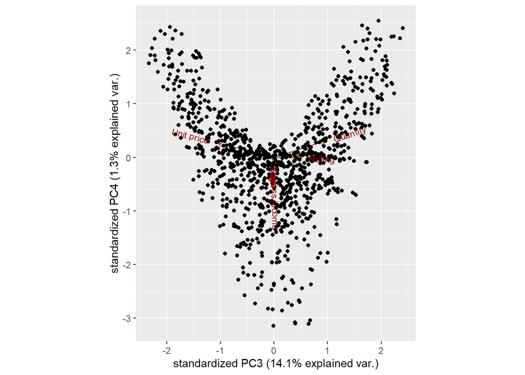

```r
# We now plot PC3 and PC4
ggbiplot(sales.pca,ellipse=TRUE,choices=c(3,4))
```

From the plot above, we can see a clear distribution of our data into three parts.

## 8.T Distributed Stochastic Neighbor Embedding - TSNE

T-SNE is a dimensionality reduction technique that is used for visualization of high dimensionality dataset. It makes it easy to understand and to explore relations between features in a dataset.

```r
# Curating the sales data for analysis
#
label.sales<-sales$Total
sales$Total = factor(sales$Total)

# For plotting
#
colors = rainbow(length(unique(sales$Total)))
names(colors) = unique(sales$Total)
```

```r
# Executing the algorithm on numeric data
library(Rtsne)
#
tsne.sales <- Rtsne(sales.1[,-7], dims = 2, perplexity=30, verbose=TRUE, max_iter = 500)
```

```
## Performing PCA
## Read the 1000 x 6 data matrix successfully!
## OpenMP is working. 1 threads.
## Using no_dims = 2, perplexity = 30.000000, and theta = 0.500000
## Computing input similarities...
## Building tree...
## Done in 0.31 seconds (sparsity = 0.102664)!
## Learning embedding...
## Iteration 50: error is 59.504110 (50 iterations in 0.28 seconds)
## Iteration 100: error is 52.503563 (50 iterations in 0.20 seconds)
## Iteration 150: error is 51.394362 (50 iterations in 0.17 seconds)
## Iteration 200: error is 50.956014 (50 iterations in 0.15 seconds)
## Iteration 250: error is 50.690843 (50 iterations in 0.14 seconds)
## Iteration 300: error is 0.572851 (50 iterations in 0.15 seconds)
## Iteration 350: error is 0.408678 (50 iterations in 0.14 seconds)
## Iteration 400: error is 0.367254 (50 iterations in 0.18 seconds)
## Iteration 450: error is 0.349131 (50 iterations in 0.14 seconds)
## Iteration 500: error is 0.340988 (50 iterations in 0.14 seconds)
## Fitting performed in 1.69 seconds.
```

```r
# Getting the duration of execution
#
exeTimeTsne <- system.time(Rtsne(sales.1[,-7], dims = 2, perplexity=30, verbose=TRUE, max_iter = 500))
```

[output not shown]

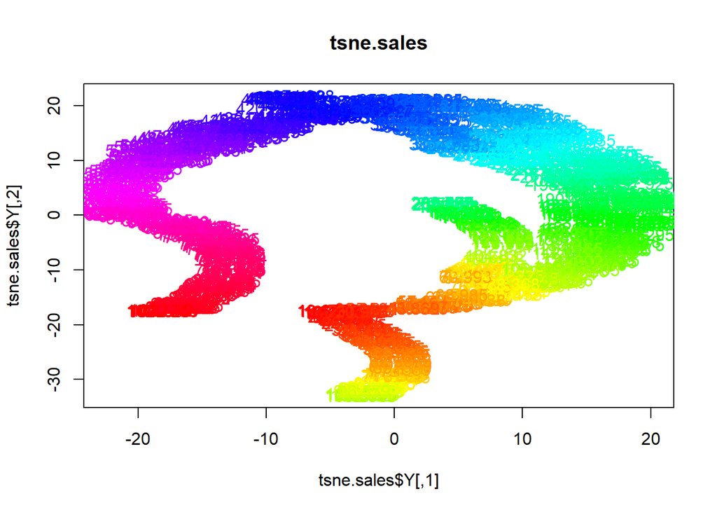

```r
# Plotting our graph and closely examining the graph

plot(tsne.sales$Y, t='n', main="tsne.sales")
text(tsne.sales$Y, labels=sales$Total, col=colors[sales$Total])
```

The total values have clearly been clustered into different groups, from very low values to the highest values

** Conclusions**

From the above study, we have managed to perform dimensionality reduction using both PCA and TSNE techniques. From the PCA, 100% of the variance was obtained from 4 components hence we can work with these 4 components. From TSNE, we have observed clusters of the total variable